# Names: Aidan Hussain

# Project Title: The Effects of Mass Shootings on Presidential Voting Trends

# Website: https://aidanhussain.github.io/cmps3160project/

This project delves into a critical and timely issue, exploring the intersection between gun violence and political trends in the United States. The primary focus is to examine how the prevalence of mass shootings influences presidential voting patterns. This research is not only academically stimulating but also has profound societal implications, offering insights into how critical issues like gun violence can shape political landscapes in the U.S.

Gun violence has been on the forefront of political rhetoric in recent years and has led to polarized stances on gun rights. With the 2024 Presidential Election less than one year away, it is crucial for each candidate/party to understand the factors that shift voting trends. The results of this analysis could influence both Democrat's and Republican's stances on the issue of gun rights moving forward. Supporting evidence of the importance of the gun rights issue as it relates to politics are linked below:

- https://www.bloomberg.com/news/articles/2023-12-08/
- https://www.pewresearch.org/politics/2023/06/28/gun-violence-widely-viewed-as-a-major-and-growing-national-problem/
- https://www.vox.com/23142734/las-vegas-unlv-mass-shooting

At the heart of our study is the question: Does an increase in gun violence in a state correlate with a shift towards the Democratic party in presidential elections?

This question stems from the Democratic party's general stance favoring stricter gun control laws.

```python
#Clone my git repository
!git clone https://github.com/aidanhussain/cmps3160project.git
%cd cmps3160project
```

```
fatal: destination path 'cmps3160project' already exists and is not an empty directory.
/content/drive/MyDrive/Colab Notebooks/cmps3160project
```

```python
#Import all the libraries we'll need
import pandas as pd
import matplotlib.pyplot as plt
import seaborn as sns
import math
import scipy.stats as stats
import numpy as np
import statsmodels.api as sm
```

# Data Set 1: US Population by State

Link: https://www.kaggle.com/datasets/alexandrepetit881234/us-population-by-state

This dataset includes each US state's piopulation as of the 2020 US Census. This dataset will be integral to normalizing/scaling raw statistics from other datasets we use throughout this project. I plan to calculate per capita deaths and injuries (using data from the mass shootings data set) using these population totals as the denominator of the per capita equations, and I also plan to use this population data to help standardize some of the data from the election datasets.

The dataset includes 5 variables relating to each state's population total. The variables of particular interest are 'State' and '2020_census' (the total population for that state as of the 2020 census).

```python
us_populations_raw = pd.read_csv("us_pop_by_state.csv")
us_populations_raw.dtypes #Check dtypes of each column
```

```
rank                float64
state                object
state_code           object
2020_census           int64
percent_of_total    float64
dtype: object
```

All the dtypes are correct. Great!

```python
us_populations_raw.head(10)
```

|  | rank | state | state_code | 2020_census | percent_of_total |
| --- | --- | --- | --- | --- | --- |
| 0 | 1.0 | California | CA | 39538223 | 0.1191 |
| 1 | 2.0 | Texas | TX | 29145505 | 0.0874 |
| 2 | 3.0 | Florida | FL | 21538187 | 0.0647 |
| 3 | 4.0 | New York | NY | 20201249 | 0.0586 |
| 4 | 5.0 | Pennsylvania | PA | 13002700 | 0.0386 |
| 5 | 6.0 | Illinois | IL | 12801989 | 0.0382 |
| 6 | 7.0 | Ohio | OH | 11799448 | 0.0352 |
| 7 | 8.0 | Georgia | GA | 10711908 | 0.0320 |
| 8 | 9.0 | North Carolina | NC | 10439388 | 0.0316 |
| 9 | 10.0 | Michigan | MI | 10077331 | 0.0301 |

Now, let's tidy this dataset up by dropping the total row, renaming the '2020_census' column to 'Population', and renaming Washington D.C.'s entry from 'DC' to 'District of Columbia'.

```python
us_populations_tidy = us_populations_raw.copy()
us_populations_tidy = us_populations_tidy[:-1] #Drop total row
us_populations_tidy = us_populations_tidy.rename({'2020_census': 'Population'}, axis=1)
us_populations_tidy = us_populations_tidy.set_index('state_code')
us_populations_tidy.at['DC', 'state'] = 'District of Columbia' #Rename Washington D.C. entry
us_populations_tidy = us_populations_tidy.reset_index()
us_populations_tidy.head(10)
```

|  | state_code | rank | state | Population | percent_of_total |
| --- | --- | --- | --- | --- | --- |
| 0 | CA | 1.0 | California | 39538223 | 0.1191 |
| 1 | TX | 2.0 | Texas | 29145505 | 0.0874 |
| 2 | FL | 3.0 | Florida | 21538187 | 0.0647 |
| 3 | NY | 4.0 | New York | 20201249 | 0.0586 |
| 4 | PA | 5.0 | Pennsylvania | 13002700 | 0.0386 |
| 5 | IL | 6.0 | Illinois | 12801989 | 0.0382 |
| 6 | OH | 7.0 | Ohio | 11799448 | 0.0352 |
| 7 | GA | 8.0 | Georgia | 10711908 | 0.0320 |
| 8 | NC | 9.0 | North Carolina | 10439388 | 0.0316 |
| 9 | MI | 10.0 | Michigan | 10077331 | 0.0301 |

# Data Set 2: US Mass Shootings

Link: https://www.kaggle.com/datasets/zusmani/us-mass-shootings-last-50-years

I am using this data set because I think that it is both interesting (in terms of the questions it can help answer) and applicable (to very real issues in the world today). My goal is to use this data set, alongside other data, to identify the effect that the prevalance of gun violence (or, more specifically, mass shootings) have on US presidential voting trends.

This data set consists of mass shootings in the United States between August 2016 and April 2021 (at least the segment of data I am using does; the actual dataset link includes other datasets with different formatting that are not being used for this project). The dataset includes 8 variables that describe each mass shooting event. The variables of particular interest include Incident Date, State, # Killed, and # Injured.

The dataset uses the FBI's definition of a mass shooting (4+ casualties excluding the shooter) as the basis for an incident's inclusion. Further informatin regarding this definition is available here: https://www.ojp.gov/ncjrs/virtual-library/abstracts/analysis-recent-mass-shootings

I think that it will be very interesting to investigate the question of whether greater prevelance of gun violence in a state has any impact on voting trends in that state. In essence, are states where gun violence is more prevelant shifting to vote more in favor of the Democratic party (typically in support of more strict gun laws)? Of course, to conduct this analysis, I will need to design this project in an appropriate way to ensure that I am answering the correct question.

```python
mass_shootings_raw = pd.read_csv("Mass shooting data.csv")
mass_shootings_raw.dtypes #Check dtypes of each column; 'Incident Date' needs to be converted to datetime

mass_shootings_raw['Incident Date'] = pd.to_datetime(mass_shootings_raw['Incident Date']) #Convert 'Incident Date' to datetime

mass_shootings_raw.dtypes #Check dtypes of each column
```

```
Incident ID                int64
Incident Date     datetime64[ns]
State                     object
City Or County            object
Address                   object
# Killed                   int64
# Injured                  int64
Operations               float64
dtype: object
```

Now that 'Incident Date's dtype is updated, dtypes are set correctly! Now, let's take a look at what data we have:

```python
mass_shootings_raw.head(10)
```

|  | Incident ID | Incident Date | State | City Or County | Address | # Killed | # Injured | Operations |
| --- | --- | --- | --- | --- | --- | --- | --- | --- |
| 0 | 1978561 | 2021-04-15 | District of Columbia | Washington | 1800 block of West Virginia Ave NE | 0 | 4 | NaN |
| 1 | 1978635 | 2021-04-15 | Indiana | Indianapolis | 8951 Mirabel Rd | 8 | 5 | NaN |
| 2 | 1978652 | 2021-04-15 | Illinois | Chicago | 600 block of N Sawyer Ave | 0 | 4 | NaN |
| 3 | 1978616 | 2021-04-15 | Florida | Pensacola | 700 Truman Ave | 0 | 6 | NaN |
| 4 | 1976538 | 2021-04-13 | Maryland | Baltimore | 2300 block of Hoffman St | 0 | 4 | NaN |
| 5 | 1975296 | 2021-04-12 | Illinois | Chicago | I-290 and S Damen Ave | 1 | 3 | NaN |
| 6 | 1974943 | 2021-04-11 | Kansas | Wichita | 200 block of N Battin St | 1 | 3 | NaN |
| 7 | 1975004 | 2021-04-11 | Washington | Seattle | 306 23rd Ave S | 0 | 4 | NaN |
| 8 | 1974088 | 2021-04-10 | Tennessee | Memphis | 4315 S 3rd St | 1 | 3 | NaN |
| 9 | 1973692 | 2021-04-10 | Missouri | Koshkonong | US-63 and MO-F | 1 | 3 | NaN |

```python
#Sum of # Killed by State
mass_shootings_raw.groupby(['State'])['# Killed'].sum().sort_values(ascending=False).head(10)
```

```
State
Texas             229
California        214
Illinois          152
Florida           134
Louisiana          84
Pennsylvania       83
Missouri           83
Ohio               79
North Carolina     77
Nevada             72
Name: # Killed, dtype: int64
```

```python
#Sum of # Killed + # Injured by State
mass_shootings_raw['# Killed or Injured'] = mass_shootings_raw['# Killed'] + mass_shootings_raw['# Injured']
mass_shootings_raw.groupby(['State'])['# Killed or Injured'].sum().sort_values(ascending=False).head(10)
```

```
State
Illinois        1069
California       969
Texas            754
Florida          649
Nevada           561
Pennsylvania     495
Louisiana        463
Ohio             424
New York         410
Missouri         344
Name: # Killed or Injured, dtype: int64
```

That's interesting: Illinois shoots past Texas and California when injuries are included (1069 killed + injured). Texas is also surpassed by California. It will be interesting to explore whether the choice of metric to measure the prevalence of gun violence makes a difference in any conclusions we draw as we progress through this project.

Anyway, now let's transform this dataset into the format we require for the purposes of our project. The goal of this transformation is to end with a dataframe that has one entry per state (the rows) and a total number of deaths, the total number of injuries, and the total number of deaths + injuries as variables (the columns) from between 2016-11-08 and 2020-11-03 (the two election days). Additionally, we want to scale the numeric variables by the state's population to ensure our data is sufficiently normalized.

We will create two versions of this dataframe: one that includes all shootings, and one that includes only shootings with 8 or more deaths.

```python
#Includes all shootings
mass_shootings_clean = mass_shootings_raw.copy()
mass_shootings_clean = mass_shootings_clean[(mass_shootings_clean['Incident Date'] > '2016-11-08') & (mass_shootings_clean['Incident Date'] < '2020-11-03')] #Filter the DF to the correct dates
mass_shootings_clean = mass_shootings_clean[['State','# Killed','# Injured','# Killed or Injured']]
mass_shootings_clean = mass_shootings_clean.groupby('State').sum()
mass_shootings_clean.head(10)
```

| State | # Killed | # Injured | # Killed or Injured |
| --- | --- | --- | --- |
| Alabama | 52 | 184 | 236 |
| Alaska | 1 | 8 | 9 |
| Arizona | 19 | 58 | 77 |
| Arkansas | 17 | 120 | 137 |
| California | 191 | 653 | 844 |
| Colorado | 22 | 106 | 128 |
| Connecticut | 10 | 59 | 69 |
| Delaware | 8 | 25 | 33 |
| District of Columbia | 13 | 131 | 144 |
| Florida | 112 | 401 | 513 |

```python
#Includes shooting with 8+ deaths
mass_shootings_clean_minimim8 = mass_shootings_raw.copy()
mass_shootings_clean_minimim8 = mass_shootings_clean_minimim8[(mass_shootings_clean_minimim8['Incident Date'] > '2016-11-08') & (mass_shootings_clean_minimim8['Incident Date'] < '2020-11-03')] #Filter the DF to the correct dates
mass_shootings_clean_minimim8 = mass_shootings_clean_minimim8[mass_shootings_clean_minimim8['# Killed'] >= 8]
mass_shootings_clean_minimim8 = mass_shootings_clean_minimim8[['State','# Killed','# Injured','# Killed or Injured']]
mass_shootings_clean_minimim8 = mass_shootings_clean_minimim8.groupby('State').sum()
mass_shootings_clean_minimim8.head(10)
```

| State | # Killed | # Injured | # Killed or Injured |
| --- | --- | --- | --- |
| California | 13 | 2 | 15 |
| Florida | 17 | 17 | 34 |
| Mississippi | 8 | 1 | 9 |
| Nevada | 59 | 441 | 500 |
| Ohio | 10 | 17 | 27 |
| Pennsylvania | 11 | 7 | 18 |
| Texas | 77 | 80 | 157 |
| Virginia | 13 | 4 | 17 |

Alright, now, let's scale these numeric variables by each state's total population per the 2020 Census.

```python
#Includes all shootings
mass_shootings_clean_normalized = mass_shootings_clean.merge(us_populations_tidy,how = 'left', left_on='State', right_on = 'state')
mass_shootings_clean_normalized['# Killed per Capita'] = mass_shootings_clean_normalized['# Killed'] / mass_shootings_clean_normalized['Population']
mass_shootings_clean_normalized['# Injured per Capita'] = mass_shootings_clean_normalized['# Injured'] / mass_shootings_clean_normalized['Population']
mass_shootings_clean_normalized['# Killed or Injured per Capita'] = mass_shootings_clean_normalized['# Killed or Injured'] / mass_shootings_clean_normalized['Population']
mass_shootings_clean_normalized = mass_shootings_clean_normalized[['state','# Killed per Capita','# Injured per Capita','# Killed or Injured per Capita']]
mass_shootings_clean_normalized.head(10)
```

|  | state | # Killed per Capita | # Injured per Capita | # Killed or Injured per Capita |
| --- | --- | --- | --- | --- |
| 0 | Alabama | 0.000010 | 0.000037 | 0.000047 |
| 1 | Alaska | 0.000001 | 0.000011 | 0.000012 |
| 2 | Arizona | 0.000003 | 0.000008 | 0.000011 |
| 3 | Arkansas | 0.000006 | 0.000040 | 0.000045 |
| 4 | California | 0.000005 | 0.000017 | 0.000021 |
| 5 | Colorado | 0.000004 | 0.000018 | 0.000022 |
| 6 | Connecticut | 0.000003 | 0.000016 | 0.000019 |
| 7 | Delaware | 0.000008 | 0.000025 | 0.000033 |
| 8 | District of Columbia | 0.000019 | 0.000190 | 0.000209 |
| 9 | Florida | 0.000005 | 0.000019 | 0.000024 |

```python
#Only includes shootings with 8+ deaths
mass_shootings_clean_normalized_minimum8 = mass_shootings_clean_minimim8.merge(us_populations_tidy,how = 'left', left_on='State', right_on = 'state')
mass_shootings_clean_normalized_minimum8['# Killed per Capita'] = mass_shootings_clean_normalized_minimum8['# Killed'] / mass_shootings_clean_normalized_minimum8['Population']
mass_shootings_clean_normalized_minimum8['# Injured per Capita'] = mass_shootings_clean_normalized_minimum8['# Injured'] / mass_shootings_clean_normalized_minimum8['Population']
mass_shootings_clean_normalized_minimum8['# Killed or Injured per Capita'] = mass_shootings_clean_normalized_minimum8['# Killed or Injured'] / mass_shootings_clean_normalized_minimum8['Population']
mass_shootings_clean_normalized_minimum8 = mass_shootings_clean_normalized_minimum8[['state','# Killed per Capita','# Injured per Capita','# Killed or Injured per Capita']]
mass_shootings_clean_normalized_minimum8.head(10)
```

|  | state | # Killed per Capita | # Injured per Capita | # Killed or Injured per Capita |
| --- | --- | --- | --- | --- |
| 0 | California | 3.287958e-07 | 5.058396e-08 | 3.793797e-07 |
| 1 | Florida | 7.892958e-07 | 7.892958e-07 | 1.578592e-06 |
| 2 | Mississippi | 2.701535e-06 | 3.376919e-07 | 3.039227e-06 |
| 3 | Nevada | 1.900397e-05 | 1.420466e-04 | 1.610506e-04 |
| 4 | Ohio | 8.474973e-07 | 1.440745e-06 | 2.288243e-06 |
| 5 | Pennsylvania | 8.459781e-07 | 5.383497e-07 | 1.384328e-06 |
| 6 | Texas | 2.641917e-06 | 2.744849e-06 | 5.386765e-06 |
| 7 | Virginia | 1.506130e-06 | 4.634246e-07 | 1.969555e-06 |

Great! Now our mass shooting/gun violence dataset is in the correct format to proceed with the rest of our project.

Its interesting that only 8 states qualify with having a mass shooting with over 8 deaths. This small number of observations will likely make it difficult to draw statistically significant conclusions, but I am still including it out of curiosity.

# Data Set 3: Results of the 2016 Presidential Elections in the United States

Link: https://www.statista.com/statistics/630799/preliminary-results-of-the-2016-presidential-election/

This dataset includes information about how each US state voted in the 2016 presidential election, by candidate. The dataset includes the 2 major candidates: Donald Trump and Hillary Clinton.

The dataset includes 3 variables relating to each state's 2016 presidential vote: 'State', (% of votes for) 'Hillary Clinton', and (% of votes for) 'Donald Trump'.

This will be one of two presidential election datasets we will use to investigate the potential effects of gun violence on American voting trends; the other dataset will feature 2020 Presidential Election results.

```python
election_results_2016_raw = pd.read_csv("2016_election_results.csv")
election_results_2016_raw.dtypes #Check dtypes of each column; need to remove extraneous column...

election_results_2016_raw = election_results_2016_raw.iloc[:,0:3] #Tidy up data
election_results_2016_raw.head(10)
```

|  | State | Hillary Clinton | Donald Trump |
| --- | --- | --- | --- |
| 0 | Alabama | 34.7 | 62.7 |
| 1 | Alaska | 37.6 | 52.8 |
| 2 | Arizona | 45.5 | 49.0 |
| 3 | Arkansas | 33.7 | 60.6 |
| 4 | California | 62.3 | 31.9 |
| 5 | Colorado | 48.2 | 43.3 |
| 6 | Connecticut | 54.7 | 41.0 |
| 7 | Delaware | 53.4 | 41.9 |
| 8 | District of Columbia | 92.8 | 4.2 |
| 9 | Florida | 47.8 | 49.0 |

Great, the datatypes are correct, and the extraneous column has been removed!

However, for consistency, let's normalize the vote proportions of Hillary Clinton and Donald Trump so they add up to 100% (because we do not care about the immaterial portion of votes for other candidiates). Also, let's rename the columns from the candidate's name to the political party's name (Hillary Clinton -> Democrat Proportion, Donald Trump -> Republican Proportion).

```python
election_results_2016_tidy = election_results_2016_raw.copy()
election_results_2016_tidy['Democrat Proportion'] = election_results_2016_tidy['Hillary Clinton'] / (election_results_2016_tidy['Hillary Clinton'] + election_results_2016_tidy['Donald Trump'])
election_results_2016_tidy['Republican Proportion'] = election_results_2016_tidy['Donald Trump'] / (election_results_2016_tidy['Hillary Clinton'] + election_results_2016_tidy['Donald Trump'])
election_results_2016_tidy = election_results_2016_tidy.drop(['Hillary Clinton','Donald Trump'], axis = 1)

election_results_2016_tidy.sort_values(by='State').head(10)
```

|  | State | Democrat Proportion | Republican Proportion |
| --- | --- | --- | --- |
| 0 | Alabama | 0.356263 | 0.643737 |
| 1 | Alaska | 0.415929 | 0.584071 |
| 2 | Arizona | 0.481481 | 0.518519 |
| 3 | Arkansas | 0.357370 | 0.642630 |
| 4 | California | 0.661359 | 0.338641 |
| 5 | Colorado | 0.526776 | 0.473224 |
| 6 | Connecticut | 0.571578 | 0.428422 |
| 7 | Delaware | 0.560336 | 0.439664 |
| 8 | District of Columbia | 0.956701 | 0.043299 |
| 9 | Florida | 0.493802 | 0.506198 |

Great! Now our data is normalized and formatted in a way that will be convenient for us as we work through this project.

# Data Set 4: 2020 USA Presidential Election Results

Link: https://www.kaggle.com/datasets/paultimothymooney/percent-voting-for-democratic-party-by-state

This dataset includes information about how each US state voted in the 2020 presidential election, by political party (Democrat or Republican).

The dataset includes 6 variables, however 3 are redundant (state identifiers). The variables of interest to us are 'state', '# DEM', and '# REP'.

This is the second presidential election dataset we will use to investigate the potential effects of gun violence on American voting trends; the other being the 2016 election results dataset from above.

```python
election_results_2020_raw = pd.read_csv("democratic_vs_republican_votes_by_usa_state_2020.csv")
election_results_2020_raw.dtypes #Check dtypes of each column

election_results_2020_raw.head(10)
```

|  | state | DEM | REP | usa_state | usa_state_code | percent_democrat |
| --- | --- | --- | --- | --- | --- | --- |
| 0 | Alabama | 843473 | 1434159 | Alabama | AL | 37.032892 |
| 1 | Alaska | 45758 | 80999 | Alaska | AK | 36.098993 |
| 2 | Arizona | 1643664 | 1626679 | Arizona | AZ | 50.259682 |
| 3 | Arkansas | 420985 | 761251 | Arkansas | AR | 35.609218 |
| 4 | California | 9315259 | 4812735 | California | CA | 65.934760 |
| 5 | Colorado | 1753416 | 1335253 | Colorado | CO | 56.769307 |
| 6 | Connecticut | 1059252 | 699079 | Connecticut | CT | 60.241900 |
| 7 | Delaware | 295413 | 199857 | Delaware | DE | 59.646859 |
| 8 | District of Columbia | 258561 | 14449 | District of Columbia | DC | 94.707520 |
| 9 | Florida | 5294767 | 5667834 | Florida | FL | 48.298456 |

The dtypes are all correct, so we are ready to proceed!

Now, let's normalize the vote proportions of Democrat and Republican votes so they add up to 100% (because we do not care about the immaterial portion of votes for other candidates). Let's also only keep the 'state' variable as an identifier for now.

```python
election_results_2020_tidy = election_results_2020_raw.copy()
election_results_2020_tidy['Democrat Proportion'] = election_results_2020_tidy['DEM'] / (election_results_2020_tidy['DEM'] + election_results_2020_tidy['REP'])
election_results_2020_tidy['Republican Proportion'] = election_results_2020_tidy['REP'] / (election_results_2020_tidy['DEM'] + election_results_2020_tidy['REP'])
election_results_2020_tidy = election_results_2020_tidy.drop(['DEM','REP','usa_state','usa_state_code','percent_democrat'], axis = 1)

election_results_2020_tidy.sort_values(by='state').head(10)
```

|  | state | Democrat Proportion | Republican Proportion |
| --- | --- | --- | --- |
| 0 | Alabama | 0.370329 | 0.629671 |
| 1 | Alaska | 0.360990 | 0.639010 |
| 2 | Arizona | 0.502597 | 0.497403 |
| 3 | Arkansas | 0.356092 | 0.643908 |
| 4 | California | 0.659348 | 0.340652 |
| 5 | Colorado | 0.567693 | 0.432307 |
| 6 | Connecticut | 0.602419 | 0.397581 |
| 7 | Delaware | 0.596469 | 0.403531 |
| 8 | District of Columbia | 0.947075 | 0.052925 |
| 9 | Florida | 0.482985 | 0.517015 |

# EXPLORATORY DATA ANALYSIS

Now, before we continue with our modeling, let's conduct some exploratory data analysis do we can start to understand the data we are working with. First, let's visualize the states with the largest population.

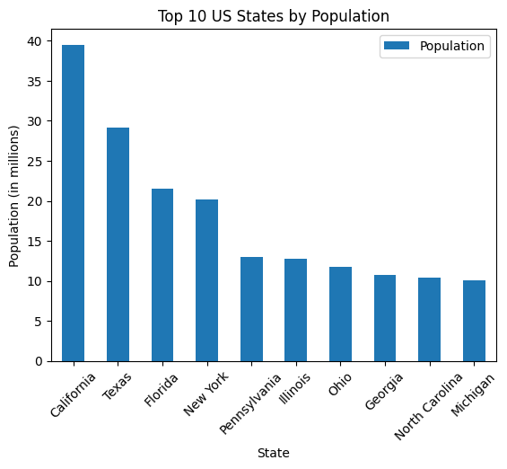

```python
#Let's visualize the states with the largest population
graph_vals = us_populations_tidy.copy()
graph_vals = graph_vals[['state','Population']]
graph_vals = graph_vals.sort_values(by='Population', ascending = False)
graph_vals['Population'] = graph_vals['Population'] / 1e6
graph_vals = graph_vals.set_index('state').head(10).iloc[0:]

graph_vals.plot.bar()
plt.ylabel('Population (in millions)')
plt.xlabel('State')
plt.title('Top 10 US States by Population')
plt.xticks(rotation=45)
plt.show()
```

This visualization helps show why California and Texas have so much gun violence (per the dataset)...they are WAY more populated. Interestingly, Illinois really isnt nearly as large as those two states, but had a lot of gun violence. That's an alarming observation!

Now, let's crate an interesting graphic. Let's see a breakdown of the number of mass shooting deaths per quarter.

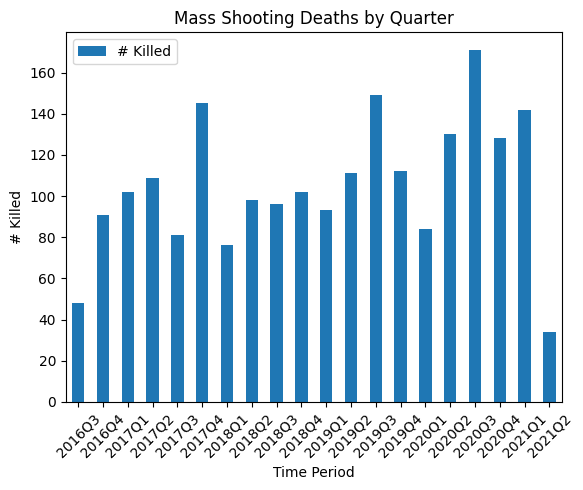

```python
#Let's visualize the # of gun deaths per quarter
graph_vals = mass_shootings_raw.copy()
graph_vals = graph_vals[['Incident Date','# Killed']]
graph_vals['Incident Month'] = graph_vals['Incident Date'].dt.to_period('Q')
graph_vals = graph_vals.groupby('Incident Month').sum()

graph_vals.plot.bar()

plt.ylabel('# Killed')
plt.xlabel('Time Period')
plt.title('Mass Shooting Deaths by Quarter')
plt.xticks(rotation=45)
plt.show()
```

```python
graph_vals.mean()/3 #Calculate average number of mass shooting deaths per month
```

```
# Killed    35.033333
dtype: float64
```

It is interesting that their seems to be some cyclicality to the graph. I wonder why? Also, the blind eye suggests that the trend is upward slanted, suggesting that gun violence deaths attributed to mass shootings seem to be on the rise. That's scary. I wonder if this trend has impacted voting trends. After all, their being 35 unnecessary, human-caused deaths per month attributed to mass shootings is certainly eye-catching.

Now, let's look at the prevalence of mass shooting deaths per state on a per capita basis.

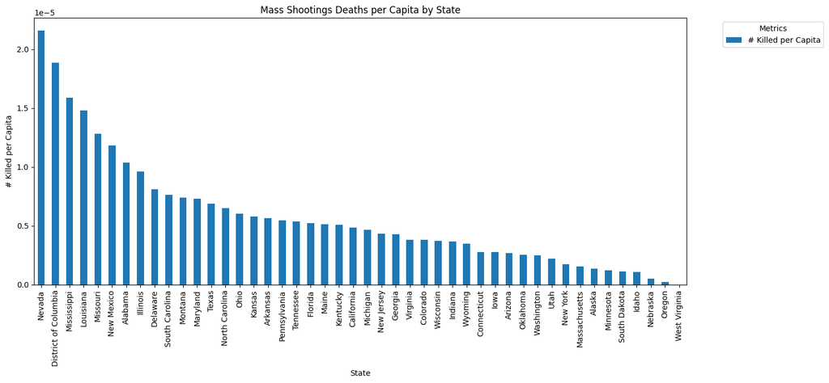

```python
import matplotlib.pyplot as plt
import pandas as pd

graph_vals = mass_shootings_clean_normalized.copy()
graph_vals = graph_vals[['state','# Killed per Capita']]
graph_vals.set_index('state', inplace=True)
graph_vals = graph_vals.sort_values(by='# Killed per Capita', ascending = False)
graph_vals.plot(kind='bar', figsize=(15, 7))

plt.title('Mass Shootings Deaths per Capita by State')
plt.xlabel('State')
plt.ylabel('# Killed per Capita')

plt.legend(title='Metrics', bbox_to_anchor=(1.05, 1), loc='upper left')

plt.tight_layout()
plt.show()
```

Interesting. Nevada is #1 (probably due to the tragic mass shooting at the music festival in Las Vegas that made national news). A harrowing look at that shooting is available here: https://www.cnn.com/interactive/2017/10/us/las-vegas-shooting-cnnphotos/

Now, if we only include shootings with 8+ deaths, how does this visualization change?

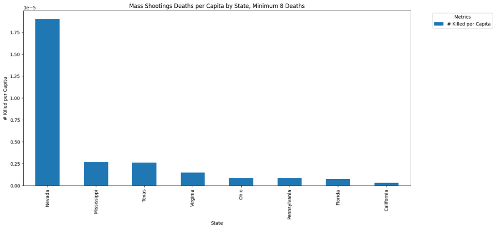

```python
graph_vals = mass_shootings_clean_normalized_minimum8.copy()
graph_vals = graph_vals[['state','# Killed per Capita']]
graph_vals.set_index('state', inplace=True)
graph_vals = graph_vals.sort_values(by='# Killed per Capita', ascending = False)
graph_vals.plot(kind='bar', figsize=(15, 7))

plt.title('Mass Shootings Deaths per Capita by State, Minimum 8 Deaths')
plt.xlabel('State')
plt.ylabel('# Killed per Capita')

plt.legend(title='Metrics', bbox_to_anchor=(1.05, 1), loc='upper left')

plt.tight_layout()
plt.show()
```

Nevada is now #1 by a LONG SHOT (not surprising). It will be interetsing to see if our decision on where to set the threshold for what counts as a mass shooting has any impact on our findings.

Now, let's take a look at some interesting graphics pertaining to how states voted in the 2016 Presidential Election. The following visualization shows the split of Democrat and Republican voting proportions in the election, starting with the highest Democrat proportion (Washington D.C.) and ending with the highest Republican proportion (Wyoming). On its own, this data does not tell us a whole lot more than the surface-level political preferences of each state, but this data will become very useful as we progress through this project!

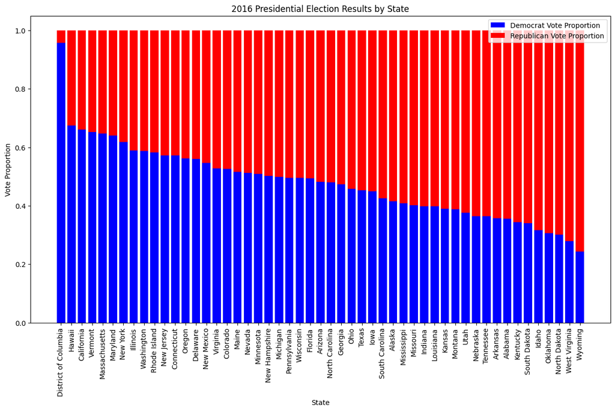

```python
# Sort by Democrat voting proportion
election_results_2016_tidy.sort_values(by='Democrat Proportion', ascending=False, inplace=True)

# Create a stacked bar chart
plt.figure(figsize=(15, 8))
plt.bar(election_results_2016_tidy['State'], election_results_2016_tidy['Democrat Proportion'], label='Democrat Vote Proportion', color='blue')
plt.bar(election_results_2016_tidy['State'], election_results_2016_tidy['Republican Proportion'], bottom=election_results_2016_tidy['Democrat Proportion'], label='Republican Vote Proportion', color='red')
plt.xlabel('State')
plt.ylabel('Vote Proportion')
plt.title('2016 Presidential Election Results by State')
plt.xticks(rotation=90)
plt.legend()
plt.show()
```

Now, let's use the same visualization technique as before to show the split of Democrat and Republican voting proportions in the 2020 Presidential Election:

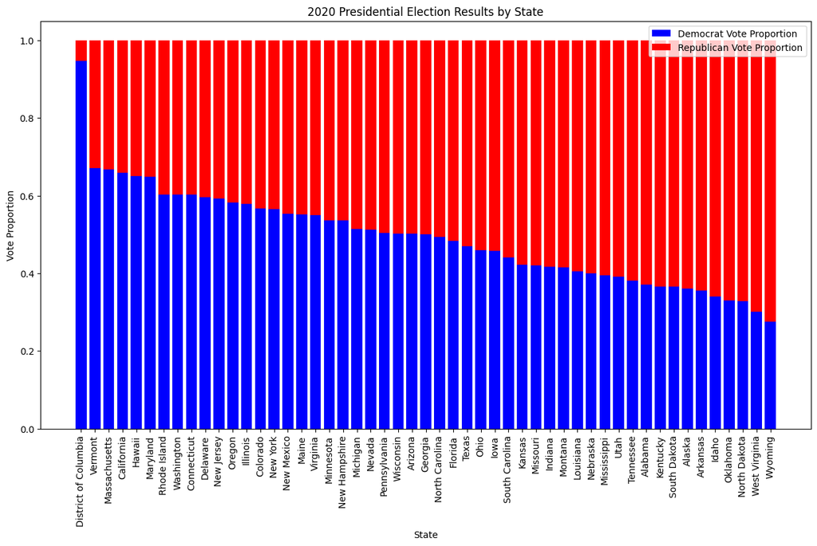

```python
# Sort by Democrat voting proportion
election_results_2020_tidy.sort_values(by='Democrat Proportion', ascending=False, inplace=True)

# Create a stacked bar chart
plt.figure(figsize=(15, 8))
plt.bar(election_results_2020_tidy['state'], election_results_2020_tidy['Democrat Proportion'], label='Democrat Vote Proportion', color='blue')
plt.bar(election_results_2020_tidy['state'], election_results_2020_tidy['Republican Proportion'], bottom=election_results_2020_tidy['Democrat Proportion'], label='Republican Vote Proportion', color='red')
plt.xlabel('State')
plt.ylabel('Vote Proportion')
plt.title('2020 Presidential Election Results by State')
plt.xticks(rotation=90)
plt.legend()
plt.show()
```

# HYPOTHESIS & FURTHER SET-UP

Given the investigative question set forth at the beginning of this project, as well as the data we have looked at thus far, my hypothesis is that an increase in the prevalence of mass gun violence in a state between 2016 and 2020 will lead to a greater shift toward the Democratic Party in the 2020 Presidential Election.

# Combining Data Sets

Now that we have loaded and tidied our datasets, let's start to combine them so we can investigate the connection between gun violence/mass shooting prevalence and voting trends.

First, let's combine the election results datasets so we can calculate the change in voting proportions from 2016 to 2020.

```python
election_results_df = election_results_2016_tidy.merge(election_results_2020_tidy, how = 'outer', left_on='State', right_on = 'state', suffixes=('_2016', '_2020'))
election_results_df = election_results_df.drop(['state'], axis=1)
election_results_df.head(10)
```

|  | State | Democrat Proportion_2016 | Republican Proportion_2016 | Democrat Proportion_2020 | Republican Proportion_2020 |
| --- | --- | --- | --- | --- | --- |
| 0 | District of Columbia | 0.956701 | 0.043299 | 0.947075 | 0.052925 |
| 1 | Hawaii | 0.674620 | 0.325380 | 0.650426 | 0.349574 |
| 2 | California | 0.661359 | 0.338641 | 0.659348 | 0.340652 |
| 3 | Vermont | 0.652081 | 0.347919 | 0.671562 | 0.328438 |
| 4 | Massachusetts | 0.646872 | 0.353128 | 0.667834 | 0.332166 |
| 5 | Maryland | 0.639875 | 0.360125 | 0.648533 | 0.351467 |
| 6 | New York | 0.617861 | 0.382139 | 0.564811 | 0.435189 |
| 7 | Illinois | 0.590095 | 0.409905 | 0.579234 | 0.420766 |
| 8 | Washington | 0.587662 | 0.412338 | 0.603309 | 0.396691 |
| 9 | Rhode Island | 0.582983 | 0.417017 | 0.603370 | 0.396630 |

Cool! Now, let's investigate this newly created dataframe. Let's calculate the change in Democrat and Republican voting proportions between 2016 and 2020.

```python
election_results_df['Democrat Proportion Change'] = election_results_df['Democrat Proportion_2020'] - election_results_df['Democrat Proportion_2016']
election_results_df['Republican Proportion Change'] = election_results_df['Republican Proportion_2020'] - election_results_df['Republican Proportion_2016']
```

Now, let's take a look at the five states with the highest increase in the proportion of Democrat votes, followed by the five states with the highest increase in the proportion of Republican votes.

```python
election_results_df.sort_values(by='Democrat Proportion Change', ascending = False).head(5)
```

|  | State | Democrat Proportion_2016 | Republican Proportion_2016 | Democrat Proportion_2020 | Republican Proportion_2020 | Democrat Proportion Change | Republican Proportion Change |
| --- | --- | --- | --- | --- | --- | --- | --- |
| 16 | Colorado | 0.526776 | 0.473224 | 0.567693 | 0.432307 | 0.040917 | -0.040917 |
| 13 | Delaware | 0.560336 | 0.439664 | 0.596469 | 0.403531 | 0.036133 | -0.036133 |
| 40 | Nebraska | 0.364793 | 0.635207 | 0.400725 | 0.599275 | 0.035932 | -0.035932 |
| 17 | Maine | 0.516129 | 0.483871 | 0.551852 | 0.448148 | 0.035723 | -0.035723 |
| 20 | New Hampshire | 0.502110 | 0.497890 | 0.536212 | 0.463788 | 0.034102 | -0.034102 |

```python
election_results_df.sort_values(by='Republican Proportion Change', ascending = False).head(5)
```

|  | State | Democrat Proportion_2016 | Republican Proportion_2016 | Democrat Proportion_2020 | Republican Proportion_2020 | Democrat Proportion Change | Republican Proportion Change |
| --- | --- | --- | --- | --- | --- | --- | --- |
| 32 | Alaska | 0.415929 | 0.584071 | 0.360990 | 0.639010 | -0.054939 | 0.054939 |
| 6 | New York | 0.617861 | 0.382139 | 0.564811 | 0.435189 | -0.053050 | 0.053050 |
| 1 | Hawaii | 0.674620 | 0.325380 | 0.650426 | 0.349574 | -0.024195 | 0.024195 |
| 33 | Mississippi | 0.409184 | 0.590816 | 0.395477 | 0.604523 | -0.013706 | 0.013706 |
| 7 | Illinois | 0.590095 | 0.409905 | 0.579234 | 0.420766 | -0.010861 | 0.010861 |

Now, let's visualize the change in Democrat vote proportion in each state:

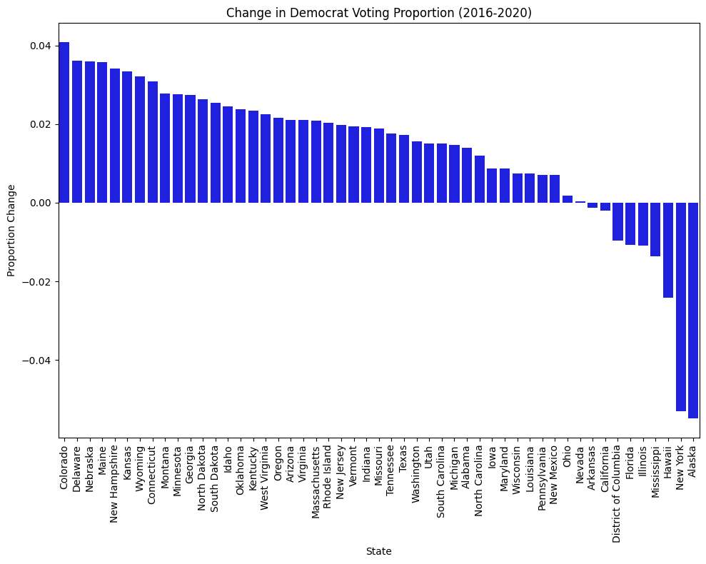

```python
election_results_df = election_results_df.sort_values(by='Democrat Proportion Change', ascending = False)

states = election_results_df['State']
dem_change = election_results_df['Democrat Proportion Change']

fig, axes = plt.subplots(nrows=1, ncols=1, figsize=(10, 8))

# Plotting Democrat Proportion Change
sns.barplot(x=states, y=dem_change, ax=axes, color="blue")
axes.set_title('Change in Democrat Voting Proportion (2016-2020)')
axes.set_ylabel('Proportion Change')
axes.set_xlabel('State')
axes.set_xticklabels(states, rotation=90)

plt.tight_layout()

plt.show()
```

Unsurprisingly, most states saw an increase in the proportion of votes cast for the Democratic party; this should be expected given the outcomes of the 2016 election (Trump beats Clinton) and 2020 election (Biden beats Trump).

However, this prompts an interesting predicament regarding what data we truly care about. If we are trying to figure our the impacts of gun violence on voting, then logically we only care about relative changes in voting proportions (relative to other states). In other words, we don't care that the entire country shifted to voting more Democratic--we care about which states shifted MORE and which shifted LESS.

Thus, let us back out the "overall voting" factor by calculating the weighted-average change in voting proportion based on state population, and subtracting that value from each state's change in proportion, thus leaving us with the proportion shifts beyond that which is expected based on overarching national voitng trend changes. We will use the weighted-average rather than the arithmetic average because each state, logically, should not be equally weighted if we are calculating a national factor.

```python
#Calculate the overall voting factor
election_results_overallfactor = election_results_df.merge(us_populations_tidy,how = 'left', left_on='State', right_on = 'state')
election_results_overallfactor = election_results_overallfactor[['State','Democrat Proportion_2016','Republican Proportion_2016','Democrat Proportion_2020','Republican Proportion_2020','Democrat Proportion Change','Republican Proportion Change','Population']]
election_results_overallfactor = election_results_overallfactor[['Democrat Proportion Change','Population']]
total_population = election_results_overallfactor['Population'].sum()
election_results_overallfactor['Contribution to Overall Factor'] = election_results_overallfactor['Population'] / total_population
election_results_overallfactor['Contribution to Overall Factor'] = election_results_overallfactor['Contribution to Overall Factor'] * election_results_overallfactor['Democrat Proportion Change']
election_results_overallfactor = election_results_overallfactor[['Contribution to Overall Factor']].sum()
election_results_overallfactor
```

```
Contribution to Overall Factor    0.007143
dtype: float64
```

Now that we have calculated the "overall voting" factor as 0.0071 (0.71%), meaning on average, a state's democrat voting proportion increased by 0.71%, we can back this out of our original calculation of the change in Democrat and Republican voting proportions.

```python
#Create columns to store our new adjusted calculations
election_results_df['Democrat Proportion Change Adjusted'] = election_results_df['Democrat Proportion Change'] - election_results_overallfactor[0]
election_results_df['Republican Proportion Change Adjusted'] = election_results_df['Republican Proportion Change'] + election_results_overallfactor[0]

#Clean up the DF by dropping unnecessary columns
election_results_df_clean = election_results_df[['State','Democrat Proportion Change Adjusted','Republican Proportion Change Adjusted']]
election_results_df_clean.head(10)
```

|  | State | Democrat Proportion Change Adjusted | Republican Proportion Change Adjusted |
| --- | --- | --- | --- |
| 16 | Colorado | 0.033774 | -0.033774 |
| 13 | Delaware | 0.028990 | -0.028990 |
| 40 | Nebraska | 0.028789 | -0.028789 |
| 17 | Maine | 0.028580 | -0.028580 |
| 20 | New Hampshire | 0.026959 | -0.026959 |
| 37 | Kansas | 0.026304 | -0.026304 |
| 50 | Wyoming | 0.025055 | -0.025055 |
| 11 | Connecticut | 0.023698 | -0.023698 |
| 38 | Montana | 0.020595 | -0.020595 |
| 19 | Minnesota | 0.020438 | -0.020438 |

Cool, now we have a clean dataframe with the variables we want (pertaining to the 2016 and 2020 US Presidential Elections).

Now, let's recreate that same visualization of the change in Democrat voting proportion, this time with the overall factor included to adjust the values.

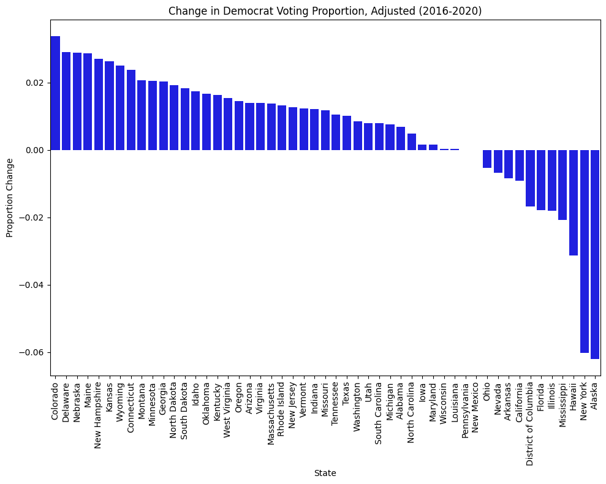

```python
election_results_df_clean = election_results_df_clean.sort_values(by='Democrat Proportion Change Adjusted', ascending = False)

states = election_results_df['State']
dem_change = election_results_df['Democrat Proportion Change Adjusted']

fig, axes = plt.subplots(nrows=1, ncols=1, figsize=(10, 8))

# Plotting Democrat Proportion Change
sns.barplot(x=states, y=dem_change, ax=axes, color="blue")
axes.set_title('Change in Democrat Voting Proportion, Adjusted (2016-2020)')
axes.set_ylabel('Proportion Change')
axes.set_xlabel('State')
axes.set_xticklabels(states, rotation=90)

plt.tight_layout()

plt.show()
```

So, very similar, but now more indicative of changes in a state (rather than at a national level).

# The Path Forward: 2 Possible Models

Now that most of our data is assembled, let's think about two ways we could possibly proceed:

# Performing Regression Analysis

Ultimately, I decided to pursure performing regressional analysis as opposed to correlation analysis because it offers greater specificity regarding the relationship between variables. Namely, regression analysis allows us a model with greater predictive power.

All the following analysis uses the mass shootings dataframe that includes all shootings...

First, we need to create a DataFrame that combines all our dependent and independent features:

```python
regression_data = mass_shootings_clean_normalized.merge(election_results_df_clean,how = 'left', left_on='state', right_on = 'State')
regression_data = regression_data[['State','# Killed per Capita','# Injured per Capita','# Killed or Injured per Capita','Democrat Proportion Change Adjusted']] #Keep only columns we want, reorder columns to dependent variable is last
regression_data.head(10)
```

|  | State | # Killed per Capita | # Injured per Capita | # Killed or Injured per Capita | Democrat Proportion Change Adjusted |
| --- | --- | --- | --- | --- | --- |
| 0 | Alabama | 0.000010 | 0.000037 | 0.000047 | 0.006923 |
| 1 | Alaska | 0.000001 | 0.000011 | 0.000012 | -0.062082 |
| 2 | Arizona | 0.000003 | 0.000008 | 0.000011 | 0.013972 |
| 3 | Arkansas | 0.000006 | 0.000040 | 0.000045 | -0.008421 |
| 4 | California | 0.000005 | 0.000017 | 0.000021 | -0.009154 |
| 5 | Colorado | 0.000004 | 0.000018 | 0.000022 | 0.033774 |
| 6 | Connecticut | 0.000003 | 0.000016 | 0.000019 | 0.023698 |
| 7 | Delaware | 0.000008 | 0.000025 | 0.000033 | 0.028990 |
| 8 | District of Columbia | 0.000019 | 0.000190 | 0.000209 | -0.016769 |
| 9 | Florida | 0.000005 | 0.000019 | 0.000024 | -0.017960 |

Great! Now we have a centralized dataframe that has all our independent and dependant variables combined in a clean, easy-to-use way!

Now, let's run some single-variable regressions to get an early idea of how our dependent and independent datapoints are related.

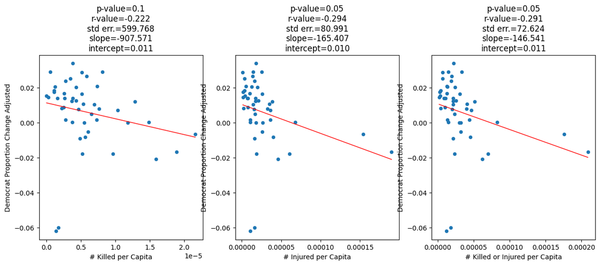

```python
x_features = ['# Killed per Capita', '# Injured per Capita', '# Killed or Injured per Capita']

#From Demo 8
def regress_with_stats(df_penrose, observations):
  fig, ax = plt.subplots(1, 3, figsize=(15,5), sharex=False)

  for i,o in enumerate(observations):
      slope, intercept, r_value, p_value, std_err = stats.linregress(df_penrose[o],
                                                                     df_penrose['Democrat Proportion Change Adjusted'])
      # Pack these into a nice title
      diag_str = "p-value=%.1g\nr-value=%.3f\nstd err.=%.3f\nslope=%.3f\nintercept=%.3f" % (p_value, r_value, std_err, slope, intercept)
      df_penrose.plot.scatter(x=o, y='Democrat Proportion Change Adjusted', title=diag_str, ax=ax[i])
      y_pred = df_penrose[o] * slope + intercept
      # Make points and line
      pts = np.linspace(df_penrose[o].min(), df_penrose[o].max(), 500)
      line = slope * pts + intercept
      ax[i].plot(pts, line, lw=1, color='red')



regress_with_stats(regression_data, x_features)
```

That is very interesting--it appears that all our independent features (that relate to mass shootings) are negatively related to the increase in the vote share Democrats received between the 2016 and 2020 Presidential elections. In other words, states that had a greater per capita prevalence of mass shooting casualties seem to have has a greater DECREASE in Democrat voting share.

However, let's run an actual multi-variable linear regression before we expand too much on this phenomenon. Let's run a regression with '# Killed per Capita' and '# Injured per Capita' as our two independent variables. I will not be scaling these independnet features because they are all related enough (per capita numbers that are directly related), so I do not see the need for scaling.

```python
df_ind = regression_data[['# Killed per Capita','# Injured per Capita']]
df_target = regression_data['Democrat Proportion Change Adjusted']

X = df_ind
y = df_target

model = sm.OLS(y, X).fit()

predictions = model.predict(X) # make the predictions by the model

# Print out the statistics
model.summary()
```

OLS Regression Results

| Dep. Variable: | Democrat Proportion Change Adjusted | R-squared (uncentered): | 0.083 |
| --- | --- | --- | --- |
| Model: | OLS | Adj. R-squared (uncentered): | 0.041 |
| Method: | Least Squares | F-statistic: | 1.980 |
| Date: | Sun, 10 Dec 2023 | Prob (F-statistic): | 0.150 |
| Time: | 16:54:44 | Log-Likelihood: | 115.91 |
| No. Observations: | 46 | AIC: | -227.8 |
| Df Residuals: | 44 | BIC: | -224.2 |
| Df Model: | 2 |  |  |
| Covariance Type: | nonrobust |  |  |

|  | coef | std err | t | P>\|t\| | [0.025 | 0.975] |
| --- | --- | --- | --- | --- | --- | --- |
| # Killed per Capita | 1653.4746 | 842.391 | 1.963 | 0.056 | -44.253 | 3351.202 |
| # Injured per Capita | -273.8772 | 145.056 | -1.888 | 0.066 | -566.218 | 18.463 |

| Omnibus: | 23.754 | Durbin-Watson: | 1.900 |
| --- | --- | --- | --- |
| Prob(Omnibus): | 0.000 | Jarque-Bera (JB): | 38.468 |
| Skew: | -1.588 | Prob(JB): | 4.43e-09 |
| Kurtosis: | 6.159 | Cond. No. | 12.7 |

Notes:  
[1] R² is computed without centering (uncentered) since the model does not contain a constant.  
[2] Standard Errors assume that the covariance matrix of the errors is correctly specified.

Interesting. So our multi-variable linear regression model assigns a positive coefficient to '# Killed per Capita' and a negative coefficient to '# Injured per Capita'. At surface level, this does not seem to make much real-world sense. It fits our hypothesis that an increase in the # Killed per Capita would increase the Democrat vote share, but it does not seem to fllow that # Injured per Capita would decrease vote share.

The coefficients on both independent features are fairly statistically significant, however, which is encouraging (P = 0.056 and P = 0.066).

Thinking abstractly, I suppose it is possible that mass shooting deaths are usually more memorable (and the statistics related to deaths are more often broadcast in the media) which could have an impact on Democrat vote share, while the # Injured may be more of a byproduct of states where guns are more widely circulated and possessed (which tend to be more Republican states), and those states may have become less Democrat leaning as a result of increased political polarization nationwide.

To try to get to the bottom of this, let's run a single-variable linear regression with '# Killed or Injured per Capita' as the lone independent variable.

```python
df_ind = regression_data[['# Killed or Injured per Capita']]
df_target = regression_data['Democrat Proportion Change Adjusted']

X = df_ind
y = df_target

model = sm.OLS(y, X).fit()

predictions = model.predict(X) # make the predictions by the model

# Print out the statistics
model.summary()
```

OLS Regression Results

| Dep. Variable: | Democrat Proportion Change Adjusted | R-squared (uncentered): | 0.001 |
| --- | --- | --- | --- |
| Model: | OLS | Adj. R-squared (uncentered): | -0.021 |
| Method: | Least Squares | F-statistic: | 0.03366 |
| Date: | Sun, 10 Dec 2023 | Prob (F-statistic): | 0.855 |
| Time: | 16:54:44 | Log-Likelihood: | 113.94 |
| No. Observations: | 46 | AIC: | -225.9 |
| Df Residuals: | 45 | BIC: | -224.1 |
| Df Model: | 1 |  |  |
| Covariance Type: | nonrobust |  |  |

|  | coef | std err | t | P>\|t\| | [0.025 | 0.975] |
| --- | --- | --- | --- | --- | --- | --- |
| # Killed or Injured per Capita | -11.1120 | 60.564 | -0.183 | 0.855 | -133.094 | 110.870 |

| Omnibus: | 27.820 | Durbin-Watson: | 1.878 |
| --- | --- | --- | --- |
| Prob(Omnibus): | 0.000 | Jarque-Bera (JB): | 53.646 |
| Skew: | -1.754 | Prob(JB): | 2.24e-12 |
| Kurtosis: | 6.960 | Cond. No. | 1.00 |

Notes:  
[1] R² is computed without centering (uncentered) since the model does not contain a constant.  
[2] Standard Errors assume that the covariance matrix of the errors is correctly specified.

Okay, so this regression has a negative coefficient, but is hardly significant (P = 0.855) so we are going to disregard this regression in terms of coming to a conclusion.

Now, let's run a full-fledged regression using only the '# Killed per Capita' as an independent feature.

```python
df_ind = regression_data[['# Killed per Capita']]
df_target = regression_data['Democrat Proportion Change Adjusted']

X = df_ind
y = df_target

model = sm.OLS(y, X).fit()

predictions = model.predict(X) # make the predictions by the model

# Print out the statistics
model.summary()
```

OLS Regression Results

| Dep. Variable: | Democrat Proportion Change Adjusted | R-squared (uncentered): | 0.008 |
| --- | --- | --- | --- |
| Model: | OLS | Adj. R-squared (uncentered): | -0.014 |
| Method: | Least Squares | F-statistic: | 0.3734 |
| Date: | Sun, 10 Dec 2023 | Prob (F-statistic): | 0.544 |
| Time: | 16:54:44 | Log-Likelihood: | 114.12 |
| No. Observations: | 46 | AIC: | -226.2 |
| Df Residuals: | 45 | BIC: | -224.4 |
| Df Model: | 1 |  |  |
| Covariance Type: | nonrobust |  |  |

|  | coef | std err | t | P>\|t\| | [0.025 | 0.975] |
| --- | --- | --- | --- | --- | --- | --- |
| # Killed per Capita | 247.3217 | 404.723 | 0.611 | 0.544 | -567.832 | 1062.475 |

| Omnibus: | 23.555 | Durbin-Watson: | 1.988 |
| --- | --- | --- | --- |
| Prob(Omnibus): | 0.000 | Jarque-Bera (JB): | 37.667 |
| Skew: | -1.584 | Prob(JB): | 6.62e-09 |
| Kurtosis: | 6.100 | Cond. No. | 1.00 |

Notes:  
[1] R² is computed without centering (uncentered) since the model does not contain a constant.  
[2] Standard Errors assume that the covariance matrix of the errors is correctly specified.

So, the coefficient on # Killed per Capita is indeed positive, but the statistical significance is still lacking (P = 0.544).

Thus, I cannot confidently draw any conclusions from this single-variable regression either.

Given the results of both of these single-variable linear regressions, I am disappointed in the lack of viable conclusions I can draw. However, the original multi-variable analysis (that had both coefficients as fairly statistically significant) continues to intrigue me, as well as the abstract explanation I arbitrarily put forth in the subsequent commentary.

My desire to build off that model (and its issues) naturally follows...

What if we added the original Republican proportion as a independent feature alongside '# Killed per Capita' to try to assess whether our uncompelling results are attributable to greater polarization in states (that are inadvertently being captured by the '# Injured per Capita' feature in the origianl multi-variable linear regression).

To do so, let's add that feature into our 'Regression_df' dataframe. Further, since we now have a variable that does not have the same (or extremely similar) distribution as '# Killed per Capita', let's scale our features.

```python
from scipy.stats import zscore

#Add 2016 Republican Proportion to regression data dataframe
regression_data_new = regression_data.merge(election_results_2016_tidy, how = 'left', on='State')
regression_data_new = regression_data_new[['# Killed per Capita','# Injured per Capita','Democrat Proportion Change Adjusted','Republican Proportion']]
regression_data_new = regression_data_new.rename(columns = {'Republican Proportion' : '2016 Republican Proportion'})



regression_data_scaled = regression_data_new.apply(zscore) #Scale our regression data using Z-Score standardization
regression_data_scaled.head(10)
```

|  | # Killed per Capita | # Injured per Capita | Democrat Proportion Change Adjusted | 2016 Republican Proportion |
| --- | --- | --- | --- | --- |
| 0 | 0.968178 | 0.304632 | 0.048431 | 0.942122 |
| 1 | -0.918970 | -0.439247 | -3.502862 | 0.460929 |
| 2 | -0.647380 | -0.520192 | 0.411214 | -0.067733 |
| 3 | -0.019845 | 0.397921 | -0.741233 | 0.933193 |
| 4 | -0.190833 | -0.277030 | -0.778971 | -1.518397 |
| 5 | -0.405121 | -0.223702 | 1.430293 | -0.433021 |
| 6 | -0.622933 | -0.281479 | 0.911743 | -0.794337 |
| 7 | 0.491780 | -0.024243 | 1.184073 | -0.703673 |
| 8 | 2.753904 | 4.741135 | -1.170850 | -3.900255 |
| 9 | -0.113279 | -0.216209 | -1.232157 | -0.167092 |

Now we have a data that is properly formatted and scaled to run our regression analysis:

```python
df_ind = regression_data_scaled[['# Killed per Capita', '2016 Republican Proportion']]
df_target = regression_data_scaled['Democrat Proportion Change Adjusted']

X = df_ind
y = df_target

model = sm.OLS(y, X).fit()

predictions = model.predict(X) # make the predictions by the model

# Print out the statistics
model.summary()
```

OLS Regression Results

| Dep. Variable: | Democrat Proportion Change Adjusted | R-squared (uncentered): | 0.099 |
| --- | --- | --- | --- |
| Model: | OLS | Adj. R-squared (uncentered): | 0.058 |
| Method: | Least Squares | F-statistic: | 2.405 |
| Date: | Sun, 10 Dec 2023 | Prob (F-statistic): | 0.102 |
| Time: | 16:54:44 | Log-Likelihood: | -62.885 |
| No. Observations: | 46 | AIC: | 129.8 |
| Df Residuals: | 44 | BIC: | 133.4 |
| Df Model: | 2 |  |  |
| Covariance Type: | nonrobust |  |  |

|  | coef | std err | t | P>\|t\| | [0.025 | 0.975] |
| --- | --- | --- | --- | --- | --- | --- |
| # Killed per Capita | -0.1592 | 0.149 | -1.070 | 0.291 | -0.459 | 0.141 |
| 2016 Republican Proportion | 0.2304 | 0.149 | 1.548 | 0.129 | -0.070 | 0.530 |

| Omnibus: | 35.854 | Durbin-Watson: | 2.022 |
| --- | --- | --- | --- |
| Prob(Omnibus): | 0.000 | Jarque-Bera (JB): | 99.764 |
| Skew: | -2.073 | Prob(JB): | 2.17e-22 |
| Kurtosis: | 8.905 | Cond. No. | 1.33 |

Notes:  
[1] R² is computed without centering (uncentered) since the model does not contain a constant.  
[2] Standard Errors assume that the covariance matrix of the errors is correctly specified.

Frustrating! Now, the coefficient on # Killed per Capita is negative (suggesting greater mass gun violence predicts a decrease in Democrat vote share), and the statistical significance is greater than on our previous model that did not include the beginning Republican voter proportion (P = 0.291 versus P = 0.544).

NOW, let's run these regressions again, but only look at mass shootings with 8 or more deaths (trying to separate out indiscriminate mass shootings from more run-of-the-mill shootings).

```python
regression_data = mass_shootings_clean_normalized_minimum8.merge(election_results_df_clean,how = 'left', left_on='state', right_on = 'State')
regression_data = regression_data[['State','# Killed per Capita','# Injured per Capita','# Killed or Injured per Capita','Democrat Proportion Change Adjusted']] #Keep only columns we want, reorder columns to dependent variable is last
regression_data.head(10)
```

|  | State | # Killed per Capita | # Injured per Capita | # Killed or Injured per Capita | Democrat Proportion Change Adjusted |
| --- | --- | --- | --- | --- | --- |
| 0 | California | 3.287958e-07 | 5.058396e-08 | 3.793797e-07 | -0.009154 |
| 1 | Florida | 7.892958e-07 | 7.892958e-07 | 1.578592e-06 | -0.017960 |
| 2 | Mississippi | 2.701535e-06 | 3.376919e-07 | 3.039227e-06 | -0.020849 |
| 3 | Nevada | 1.900397e-05 | 1.420466e-04 | 1.610506e-04 | -0.006744 |
| 4 | Ohio | 8.474973e-07 | 1.440745e-06 | 2.288243e-06 | -0.005255 |
| 5 | Pennsylvania | 8.459781e-07 | 5.383497e-07 | 1.384328e-06 | -0.000096 |
| 6 | Texas | 2.641917e-06 | 2.744849e-06 | 5.386765e-06 | 0.010151 |
| 7 | Virginia | 1.506130e-06 | 4.634246e-07 | 1.969555e-06 | 0.013921 |

Now, let's run some single-variable regressions to get an early idea of how our dependent and independent datapoints are related.

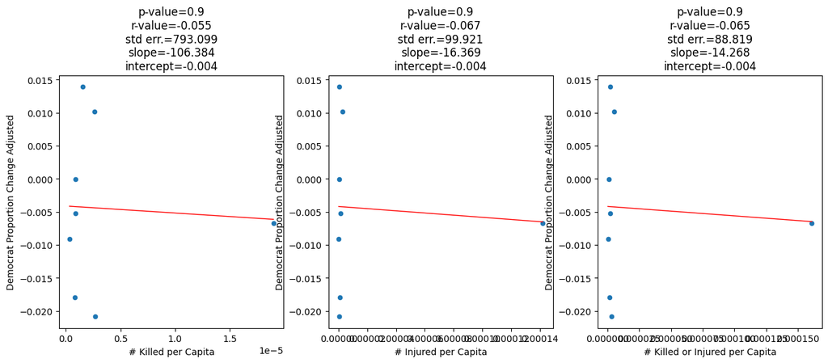

```python
x_features = ['# Killed per Capita', '# Injured per Capita', '# Killed or Injured per Capita']

#From Demo 8
def regress_with_stats(df_penrose, observations):
  fig, ax = plt.subplots(1, 3, figsize=(15,5), sharex=False)

  for i,o in enumerate(observations):
      slope, intercept, r_value, p_value, std_err = stats.linregress(df_penrose[o],
                                                                     df_penrose['Democrat Proportion Change Adjusted'])
      # Pack these into a nice title
      diag_str = "p-value=%.1g\nr-value=%.3f\nstd err.=%.3f\nslope=%.3f\nintercept=%.3f" % (p_value, r_value, std_err, slope, intercept)
      df_penrose.plot.scatter(x=o, y='Democrat Proportion Change Adjusted', title=diag_str, ax=ax[i])
      y_pred = df_penrose[o] * slope + intercept
      # Make points and line
      pts = np.linspace(df_penrose[o].min(), df_penrose[o].max(), 500)
      line = slope * pts + intercept
      ax[i].plot(pts, line, lw=1, color='red')



regress_with_stats(regression_data, x_features)
```

Again, it appears that all our independent features (that relate to mass shootings) are negatively related to the increase in the vote share Democrats received between the 2016 and 2020 Presidential elections. In other words, states that had a greater per capita prevalence of mass shooting casualties seem to have has a greater DECREASE in Democrat voting share.

Let's run a regression with '# Killed per Capita' as our independent variable.

```python
df_ind = regression_data[['# Killed per Capita']]
df_target = regression_data['Democrat Proportion Change Adjusted']

X = df_ind
y = df_target

model = sm.OLS(y, X).fit()

predictions = model.predict(X) # make the predictions by the model

# Print out the statistics
model.summary()
```

OLS Regression Results

| Dep. Variable: | Democrat Proportion Change Adjusted | R-squared (uncentered): | 0.055 |
| --- | --- | --- | --- |
| Model: | OLS | Adj. R-squared (uncentered): | -0.080 |
| Method: | Least Squares | F-statistic: | 0.4040 |
| Date: | Sun, 10 Dec 2023 | Prob (F-statistic): | 0.545 |
| Time: | 16:54:47 | Log-Likelihood: | 24.056 |
| No. Observations: | 8 | AIC: | -46.11 |
| Df Residuals: | 7 | BIC: | -46.03 |
| Df Model: | 1 |  |  |
| Covariance Type: | nonrobust |  |  |

|  | coef | std err | t | P>\|t\| | [0.025 | 0.975] |
| --- | --- | --- | --- | --- | --- | --- |
| # Killed per Capita | -417.0750 | 656.184 | -0.636 | 0.545 | -1968.703 | 1134.553 |

| Omnibus: | 0.500 | Durbin-Watson: | 0.621 |
| --- | --- | --- | --- |
| Prob(Omnibus): | 0.779 | Jarque-Bera (JB): | 0.465 |
| Skew: | 0.031 | Prob(JB): | 0.793 |
| Kurtosis: | 1.821 | Cond. No. | 1.00 |

Notes:  
[1] R² is computed without centering (uncentered) since the model does not contain a constant.  
[2] Standard Errors assume that the covariance matrix of the errors is correctly specified.

So only including these mass shootings with 8+ detahs, the coefficient on # Killed per Capita is negative, but the P-value is far from statistically significant (P=0.545).

Now, let's again add in the 2016 Republican vote share to make sure we do not ignore potential effects of polarization.

```python
from scipy.stats import zscore

#Add 2016 Republican Proportion to regression data dataframe
regression_data_new = regression_data.merge(election_results_2016_tidy, how = 'left', on='State')
regression_data_new = regression_data_new[['# Killed per Capita','# Injured per Capita','Democrat Proportion Change Adjusted','Republican Proportion']]
regression_data_new = regression_data_new.rename(columns = {'Republican Proportion' : '2016 Republican Proportion'})



regression_data_scaled = regression_data_new.apply(zscore) #Scale our regression data using Z-Score standardization
regression_data_scaled.head(10)
```

|  | # Killed per Capita | # Injured per Capita | Democrat Proportion Change Adjusted | 2016 Republican Proportion |
| --- | --- | --- | --- | --- |
| 0 | -0.552904 | -0.396303 | -0.406560 | -2.279994 |
| 1 | -0.474667 | -0.380480 | -1.175525 | 0.111112 |
| 2 | -0.149782 | -0.390153 | -1.427815 | 1.318644 |
| 3 | 2.619958 | 2.645367 | -0.196133 | -0.160686 |
| 4 | -0.464778 | -0.366525 | -0.066067 | 0.627843 |
| 5 | -0.465037 | -0.385855 | 0.384399 | 0.074417 |
| 6 | -0.159911 | -0.338590 | 1.279250 | 0.691584 |
| 7 | -0.352878 | -0.387460 | 1.608451 | -0.382920 |

```python
df_ind = regression_data_scaled[['# Killed per Capita', '2016 Republican Proportion']]
df_target = regression_data_scaled['Democrat Proportion Change Adjusted']

X = df_ind
y = df_target

model = sm.OLS(y, X).fit()

predictions = model.predict(X) # make the predictions by the model

# Print out the statistics
model.summary()
```

OLS Regression Results

| Dep. Variable: | Democrat Proportion Change Adjusted | R-squared (uncentered): | 0.013 |
| --- | --- | --- | --- |
| Model: | OLS | Adj. R-squared (uncentered): | -0.317 |
| Method: | Least Squares | F-statistic: | 0.03825 |
| Date: | Sun, 10 Dec 2023 | Prob (F-statistic): | 0.963 |
| Time: | 16:54:47 | Log-Likelihood: | -11.301 |
| No. Observations: | 8 | AIC: | 26.60 |
| Df Residuals: | 6 | BIC: | 26.76 |
| Df Model: | 2 |  |  |
| Covariance Type: | nonrobust |  |  |

|  | coef | std err | t | P>\|t\| | [0.025 | 0.975] |
| --- | --- | --- | --- | --- | --- | --- |
| # Killed per Capita | -0.0512 | 0.406 | -0.126 | 0.904 | -1.044 | 0.942 |
| 2016 Republican Proportion | -0.0980 | 0.406 | -0.242 | 0.817 | -1.091 | 0.895 |

| Omnibus: | 0.702 | Durbin-Watson: | 0.374 |
| --- | --- | --- | --- |
| Prob(Omnibus): | 0.704 | Jarque-Bera (JB): | 0.556 |
| Skew: | 0.255 | Prob(JB): | 0.757 |
| Kurtosis: | 1.813 | Cond. No. | 1.04 |

Notes:  
[1] R² is computed without centering (uncentered) since the model does not contain a constant.  
[2] Standard Errors assume that the covariance matrix of the errors is correctly specified.

So, even trying to drill down to only the more "traditional" mass shootings, my findings still dispute the hypothesis that an increase in mass shootings leads to a greater Democrat vote share.

# Conclusion

Given the results of my models, the only logical conclusion I can draw is that it appears that an increased prevalence of mass gun violence (regardless of how its measured) does NOT suggest a greater increase in the Democrat vote share in the next presidential election. In fact, my findings, altough not statistically significant, actually indicate the opposite: that Republicans tend to see a relative increase in their vote share in states that experience more mass shooting violence. While that does not (to me, at least) make much intuitive sense, the numbers are the numbers. A real world take away from this analysis could be that Democrats should focus less on gun control in their political rhetoric, while Republicans may be wise to continue to remain fixed on their pro gun rights stances.

# Collaboration Plan

For this project, I plan to work solo, so I will not need to collobrate with a partner. Yet, it is still crucial to formulate a plan to ensure that I stay on track regarding working on the project. As such, I plan to set aside a specific block of time each week to work on this project, thereby ensuring that I do not fall behind and risk submitting a project without the adequate level of detail expected.

```python
#Download as HTML...
from google.colab import drive
drive.mount('/content/drive')
```

```python
%cd /content/drive/MyDrive/'Colab Notebooks'
```

```
/content/drive/MyDrive/Colab Notebooks
```

```python
%%shell
jupyter nbconvert --to html 'CMPS3160 Voting Project.ipynb'
```

```
[NbConvertApp] Converting notebook CMPS3160 Voting Project.ipynb to html
[NbConvertApp] Writing 725785 bytes to CMPS3160 Voting Project.html
```